# Trabalho 1 - Método Numéricos (PEC00141)

1.Dados

2.Inserindo os dados

3.Plotagem da estrutura

4.Comprimento das barras e cos e sen diretores

5.Montagem da matriz de rigidez

6.Aplicação das condições de contorno

6.1 Montagem do vetor de forças

7.Resolução da equação de equilíbrio

8.Plotagem da treliça deformada

9.Determinação dos esforços

## 1. Dados

Para a estrutura ilustrada na figura abaixo:

[figure not shown]

As áreas das barras 1,2 3,4, 5 e 6 em 10E03 mm², são, respectivamente: 25, 30, 30, 25, 30 e 10. E=200GPa.

## 2. Inserindo os dados

Importação de módulos que serão utilizados

```python
import pandas as pd
import numpy as np
import matplotlib.pyplot as plt
```

Importação do excel (as unidades estão em metros e em Newtons):

```python
nos = pd.read_excel('dados_de_entrada.xlsx', sheet_name='Nós')
barras = pd.read_excel('dados_de_entrada.xlsx', sheet_name='Barras')

# Acertando os números dos nós e das barras conforme a figura (iniciando em 1)
nos.index += 1
barras.index += 1

# Trocando celulas vazias por zeros
nos.fillna(0, inplace=True)

# Printando os valores na tela
nos
```

|  | X | Y | RX | RY | FX | FY | dx | dy |
| --- | --- | --- | --- | --- | --- | --- | --- | --- |
| 1 | 0 | 0 | 1.0 | 1.0 | 0.0 | 0.0 | 0.0 | 0.0 |
| 2 | 6 | 0 | 0.0 | 1.0 | 0.0 | 0.0 | 0.0 | 0.0 |
| 3 | 3 | 4 | 0.0 | 0.0 | 200000.0 | 0.0 | 0.0 | 0.0 |
| 4 | 6 | 8 | 0.0 | 0.0 | 0.0 | 0.0 | 0.0 | 0.0 |
| 5 | 0 | 8 | 1.0 | 1.0 | 0.0 | 0.0 | 0.0 | 0.0 |

```python
barras
```

|  | N1 | N2 | A | E |
| --- | --- | --- | --- | --- |
| 1 | 1 | 2 | 0.025 | 200000000000 |
| 2 | 1 | 3 | 0.030 | 200000000000 |
| 3 | 2 | 3 | 0.030 | 200000000000 |
| 4 | 2 | 4 | 0.025 | 200000000000 |
| 5 | 3 | 4 | 0.030 | 200000000000 |
| 6 | 4 | 5 | 0.010 | 200000000000 |

## 3. Plotagem da estrutura

O código abaixo permite a montagem da estrutura plotando elemento a elemento a partir das matrizes das barras e dos nós.

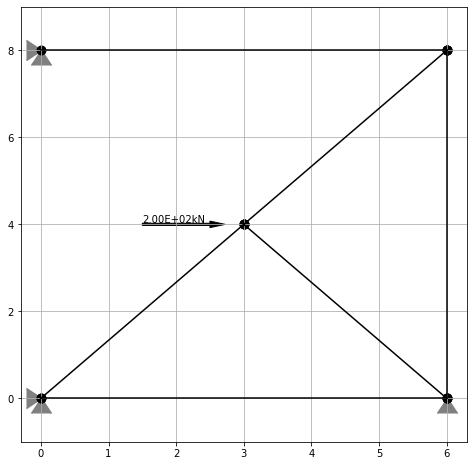

```python
plt.figure(1,figsize=(8,8))
plt.ylim(-1,9)

# Plotagem dos apoios e das forças
for no in nos.index:
    X,Y,RX,RY,Fx,Fy,dx,dy = nos.loc[no]  #percorre os valores de X,Y,RX,RY,Fx,Fy,dx,dy na tabela para cada no do for (1,2,3 e 4)

    # Aplicação dos vínculos (Se RX restrito aplica sobre gl de X)
    if RX == 1:
        plt.scatter(X,Y,400,marker =5,zorder = -2,color ='gray')
    if RY == 1:
        plt.scatter(X,Y,400,marker =6,zorder = -2,color ='gray')

    # Aplicação das forças
    if Fx >0:
        plt.arrow(X-1.5,Y,1,0,width =0.05,color='k')
        plt.text(X-1.5,Y,'{:.2E}kN'.format(Fx/1000),va='bottom')
    if Fx <0:
       plt.arrow(X+1.5,Y,-1,0,width =0.05,color='k')
       plt.text(X+.5,Y,'{:.2E}kN'.format(Fx/1000),va='bottom')
    if Fy >0:
        plt.arrow(X,Y-1.5,0,1,width =0.05,color='k')
        plt.text(X,Y,'{:.2E}kN'.format(Fy/1000),va='bottom',rotation=90)
    if Fy <0:
       plt.arrow(X,Y+1.5,0,-1,width =0.05,color='k')
       plt.text(X,Y+.5,'{:.2E}kN'.format(Fy/1000),ha='right',rotation=90)

    # Aplicação dos deslocamentos
    if dx != 0:
        plt.text(X+0.5,Y-0.5,'Δx={}m'.format(dx),color='black')
    if dy != 0:
        plt.text(X+0.5,Y-0.5,'Δy={}m'.format(dy),color='black')

# Plotagem das barras
for barra in barras.index:
    # Vamos passar os nós para as variáveis N1 e N2
    N1 = barras.loc[barra, 'N1']
    N2 = barras.loc[barra, 'N2']

    # Agora vamos acessar as coordendas de cada um dos nós
    x1, y1 = nos.loc[N1, ['X','Y']]
    x2, y2 = nos.loc[N2, ['X','Y']]
    y = [y1,y2]
    x = [x1,x2]

    plt.plot(x,y,'black')
    plt.scatter(x,y, s=80,marker ='o',color ='black')
    plt.grid(True)
```

`!É uma forma de conferir se os dados foram inseridos de maneira correta, ou seja, a imagem gerada deve ser compatível com a do problema proposto!`

## 4. Comprimento das barras e cos e sen diretores

Percorre-se o **DataFrame** de `barras` e a cada passo acessa o **DataFrame** de `nos` para obter suas coordendas. Os valores cálculados serão armazenados em **listas** que serão inseridas no **DataFrame** ao fim do processo.

```python
# Criação de listas vazias para armazenar as variáves
Ls   = []
sens = []
coss = []

for barra in barras.index:
    # Vamos passar os nós para as variáveis N1 e N2. Por exemplo: quando  barra=4 (no for), N1=3 e N2=4
    N1 = barras.loc[barra, 'N1']
    N2 = barras.loc[barra, 'N2']

    # Agora vamos acessar as coordendas de cada um dos nós. Por exemplo: quando  barra=4 (no for), x1=5, y1=8.66, x2=10, y2=8.66
    x1, y1 = nos.loc[N1, ['X','Y']]
    x2, y2 = nos.loc[N2, ['X','Y']]

    # O comprimento da barra é dado pelo teorema de Pitagoras
    Lx = x2 - x1
    Ly = y2 - y1
    L = np.sqrt(Lx**2 + Ly**2)

    # Os cossenos diretores são então:
    sen = Ly/L
    cos = Lx/L

    # Inserindo nas listas
    Ls.append(L)
    sens.append(sen)
    coss.append(cos)

# Agora que saimos do loop vamos inserir no DataFrame
barras['L']   = Ls
barras['sen'] = sens
barras['cos'] = coss

# Printando novo DataFrame
barras
```

|  | N1 | N2 | A | E | L | sen | cos |
| --- | --- | --- | --- | --- | --- | --- | --- |
| 1 | 1 | 2 | 0.025 | 200000000000 | 6.0 | 0.0 | 1.0 |
| 2 | 1 | 3 | 0.030 | 200000000000 | 5.0 | 0.8 | 0.6 |
| 3 | 2 | 3 | 0.030 | 200000000000 | 5.0 | 0.8 | -0.6 |
| 4 | 2 | 4 | 0.025 | 200000000000 | 8.0 | 1.0 | 0.0 |
| 5 | 3 | 4 | 0.030 | 200000000000 | 5.0 | 0.8 | 0.6 |
| 6 | 4 | 5 | 0.010 | 200000000000 | 6.0 | 0.0 | -1.0 |

## 5. Montagem da matriz de rigidez

A matriz de rigidez global é a obtida pela superposição das matrizes de rigidez locais nos respectivos graus de liberdade. Inicialmente a matriz global `K` deve ser pré alocada como uma matriz de zeros.

```python
maxgl = 2*len(nos)
K = np.zeros([maxgl,maxgl])
```

A alocação é realizada percorrendo todas as barras novamente, cálculando suas matrizes de rigidez local e alocando suas componentes na matriz global.

```python
for barra in barras.index:
    # Vamos importar as propriedades necessárias para construção da matriz local e da matriz de rotação
    L   = barras.loc[barra, 'L']
    sen = barras.loc[barra, 'sen']
    cos = barras.loc[barra, 'cos']
    A   = barras.loc[barra, 'A']
    E   = barras.loc[barra, 'E']
    N1  = barras.loc[barra, 'N1']
    N2  = barras.loc[barra, 'N2']

    # Matriz de rigidez no sistema local
    Kl = E*A/L*np.array([[ 1, 0,-1, 0],
                         [ 0, 0, 0, 0],
                         [-1, 0, 1, 0],
                         [ 0, 0, 0, 0]])

    # Matriz de rotação
    Mrot = np.array([[ cos,  sen,    0,   0],
                     [-sen,  cos,    0,   0],
                     [    0,   0,  cos, sen],
                     [    0,   0, -sen, cos]])

    # Rotação da matriz de coordenadas locais para globais, o np.dot é para multiplicação das matrizes
    Klr = np.dot(np.dot(Mrot.T, Kl), Mrot)

    print (Klr)

    # Cálculo dos graus de liberdade
    gl1 = 2*N1 - 1
    gl2 = 2*N1
    gl3 = 2*N2 - 1
    gl4 = 2*N2

    # Aloca a matriz local na matriz global
    # Lembrando as propriedades das listas do Python!
    K[gl1-1:gl2, gl1-1:gl2] += Klr[0:2, 0:2]
    K[gl3-1:gl4, gl1-1:gl2] += Klr[2:4, 0:2]
    K[gl1-1:gl2, gl3-1:gl4] += Klr[0:2, 2:4]
    K[gl3-1:gl4, gl3-1:gl4] += Klr[2:4, 2:4]
```

```
[[ 8.33333333e+08  0.00000000e+00 -8.33333333e+08  0.00000000e+00]
 [ 0.00000000e+00  0.00000000e+00  0.00000000e+00  0.00000000e+00]
 [-8.33333333e+08  0.00000000e+00  8.33333333e+08  0.00000000e+00]
 [ 0.00000000e+00  0.00000000e+00  0.00000000e+00  0.00000000e+00]]
[[ 4.32e+08  5.76e+08 -4.32e+08 -5.76e+08]
 [ 5.76e+08  7.68e+08 -5.76e+08 -7.68e+08]
 [-4.32e+08 -5.76e+08  4.32e+08  5.76e+08]
 [-5.76e+08 -7.68e+08  5.76e+08  7.68e+08]]
[[ 4.32e+08 -5.76e+08 -4.32e+08  5.76e+08]
 [-5.76e+08  7.68e+08  5.76e+08 -7.68e+08]
 [-4.32e+08  5.76e+08  4.32e+08 -5.76e+08]
 [ 5.76e+08 -7.68e+08 -5.76e+08  7.68e+08]]
[[ 0.00e+00  0.00e+00  0.00e+00  0.00e+00]
 [ 0.00e+00  6.25e+08  0.00e+00 -6.25e+08]
 [ 0.00e+00  0.00e+00  0.00e+00  0.00e+00]
 [ 0.00e+00 -6.25e+08  0.00e+00  6.25e+08]]
[[ 4.32e+08  5.76e+08 -4.32e+08 -5.76e+08]
 [ 5.76e+08  7.68e+08 -5.76e+08 -7.68e+08]
 [-4.32e+08 -5.76e+08  4.32e+08  5.76e+08]
 [-5.76e+08 -7.68e+08  5.76e+08  7.68e+08]]
[[ 3.33333333e+08  0.00000000e+00 -3.33333333e+08  0.00000000e+00]
 [ 0.00000000e+00  0.00000000e+00  0.00000000e+00  0.00000000e+00]
 [-3.33333333e+08  0.00000000e+00  3.33333333e+08  0.00000000e+00]
 [ 0.00000000e+00  0.00000000e+00  0.00000000e+00  0.00000000e+00]]
```

## 6. Aplicação das condições de contorno

Agora, para solução do problema, a matriz de rigidez global é clonada e as restrições de apoio são impostas zerando as respectivas linhas e colunas.

```python
Kcompleta = K.copy()    # Alocando a matriz em outro espaço de memória, pois vou mudar o K,  as será "conservado" em Kcompleta

for no in nos.index:
    RX, RY, dx, dy = nos.loc[no, ['RX','RY','dx','dy']]
    # Se RX restrito aplica sobre gl de X
    if RX == 1:
        gl = 2*no - 1
        K[:,    gl-1] = 0
        K[gl-1,    :] = 0
        K[gl-1, gl-1] = 1
        print('Aplicando restrição horizontal no nó {:d}.'.format(no))

    if RY == 1:
        gl = 2*no
        K[:,    gl-1] = 0
        K[gl-1,    :] = 0
        K[gl-1, gl-1] = 1
        print('Aplicando restrição vertical no nó {:d}.'.format(no))

    # Restrições de deslocamento
    if dx != 0:
        gl = 2*no - 1
        K[:,    gl-1] = 0
        K[gl-1,    :] = 0
        K[gl-1, gl-1] = 1
        print('Aplicando restrição horizontal devido ao deslocamento no nó {:d}.'.format(no))

    if dy != 0:
        gl = 2*no
        K[:,    gl-1] = 0
        K[gl-1,    :] = 0
        K[gl-1, gl-1] = 1
        print('Aplicando restrição vertical devido ao deslocamento no nó {:d}.'.format(no))
```

```
Aplicando restrição horizontal no nó 1.
Aplicando restrição vertical no nó 1.
Aplicando restrição vertical no nó 2.
Aplicando restrição horizontal no nó 5.
Aplicando restrição vertical no nó 5.
```

```python
#print (Kcompleta,'\n')
#print (K)

Kcompletadf = pd.DataFrame(Kcompleta)
Kdf = pd.DataFrame(K)

Kcompletadf
```

|  | 0 | 1 | 2 | 3 | 4 | 5 | 6 | 7 | 8 | 9 |
| --- | --- | --- | --- | --- | --- | --- | --- | --- | --- | --- |
| 0 | 1.265333e+09 | 576000000.0 | -8.333333e+08 | 0.000000e+00 | -4.320000e+08 | -5.760000e+08 | 0.000000e+00 | 0.000000e+00 | 0.000000e+00 | 0.0 |
| 1 | 5.760000e+08 | 768000000.0 | 0.000000e+00 | 0.000000e+00 | -5.760000e+08 | -7.680000e+08 | 0.000000e+00 | 0.000000e+00 | 0.000000e+00 | 0.0 |
| 2 | -8.333333e+08 | 0.0 | 1.265333e+09 | -5.760000e+08 | -4.320000e+08 | 5.760000e+08 | 0.000000e+00 | 0.000000e+00 | 0.000000e+00 | 0.0 |
| 3 | 0.000000e+00 | 0.0 | -5.760000e+08 | 1.393000e+09 | 5.760000e+08 | -7.680000e+08 | 0.000000e+00 | -6.250000e+08 | 0.000000e+00 | 0.0 |
| 4 | -4.320000e+08 | -576000000.0 | -4.320000e+08 | 5.760000e+08 | 1.296000e+09 | 5.760000e+08 | -4.320000e+08 | -5.760000e+08 | 0.000000e+00 | 0.0 |
| 5 | -5.760000e+08 | -768000000.0 | 5.760000e+08 | -7.680000e+08 | 5.760000e+08 | 2.304000e+09 | -5.760000e+08 | -7.680000e+08 | 0.000000e+00 | 0.0 |
| 6 | 0.000000e+00 | 0.0 | 0.000000e+00 | 0.000000e+00 | -4.320000e+08 | -5.760000e+08 | 7.653333e+08 | 5.760000e+08 | -3.333333e+08 | 0.0 |
| 7 | 0.000000e+00 | 0.0 | 0.000000e+00 | -6.250000e+08 | -5.760000e+08 | -7.680000e+08 | 5.760000e+08 | 1.393000e+09 | 0.000000e+00 | 0.0 |
| 8 | 0.000000e+00 | 0.0 | 0.000000e+00 | 0.000000e+00 | 0.000000e+00 | 0.000000e+00 | -3.333333e+08 | 0.000000e+00 | 3.333333e+08 | 0.0 |
| 9 | 0.000000e+00 | 0.0 | 0.000000e+00 | 0.000000e+00 | 0.000000e+00 | 0.000000e+00 | 0.000000e+00 | 0.000000e+00 | 0.000000e+00 | 0.0 |

```python
Kdf
```

|  | 0 | 1 | 2 | 3 | 4 | 5 | 6 | 7 | 8 | 9 |
| --- | --- | --- | --- | --- | --- | --- | --- | --- | --- | --- |
| 0 | 1.0 | 0.0 | 0.000000e+00 | 0.0 | 0.000000e+00 | 0.000000e+00 | 0.000000e+00 | 0.000000e+00 | 0.0 | 0.0 |
| 1 | 0.0 | 1.0 | 0.000000e+00 | 0.0 | 0.000000e+00 | 0.000000e+00 | 0.000000e+00 | 0.000000e+00 | 0.0 | 0.0 |
| 2 | 0.0 | 0.0 | 1.265333e+09 | 0.0 | -4.320000e+08 | 5.760000e+08 | 0.000000e+00 | 0.000000e+00 | 0.0 | 0.0 |
| 3 | 0.0 | 0.0 | 0.000000e+00 | 1.0 | 0.000000e+00 | 0.000000e+00 | 0.000000e+00 | 0.000000e+00 | 0.0 | 0.0 |
| 4 | 0.0 | 0.0 | -4.320000e+08 | 0.0 | 1.296000e+09 | 5.760000e+08 | -4.320000e+08 | -5.760000e+08 | 0.0 | 0.0 |
| 5 | 0.0 | 0.0 | 5.760000e+08 | 0.0 | 5.760000e+08 | 2.304000e+09 | -5.760000e+08 | -7.680000e+08 | 0.0 | 0.0 |
| 6 | 0.0 | 0.0 | 0.000000e+00 | 0.0 | -4.320000e+08 | -5.760000e+08 | 7.653333e+08 | 5.760000e+08 | 0.0 | 0.0 |
| 7 | 0.0 | 0.0 | 0.000000e+00 | 0.0 | -5.760000e+08 | -7.680000e+08 | 5.760000e+08 | 1.393000e+09 | 0.0 | 0.0 |
| 8 | 0.0 | 0.0 | 0.000000e+00 | 0.0 | 0.000000e+00 | 0.000000e+00 | 0.000000e+00 | 0.000000e+00 | 1.0 | 0.0 |
| 9 | 0.0 | 0.0 | 0.000000e+00 | 0.0 | 0.000000e+00 | 0.000000e+00 | 0.000000e+00 | 0.000000e+00 | 0.0 | 1.0 |

### 6.1 Montagem do vetor de forças

Com a matriz global restringida é mmontado o vetor de forças aplicadas. Este vetor tem como dimensão o número de graus de liberdade.

```python
F = np.zeros(maxgl)
Fauxf = np.zeros(maxgl)  #vetor das forças aplicadas
Fauxd = np.zeros(maxgl)  #vetor das forças devido aos deslocamentos sofridos
Fauxdx = np.zeros(maxgl)  #para contar
Fauxdy = np.zeros(maxgl)  #para contar

for no in nos.index:
    RX, RY, FX, FY, dx, dy = nos.loc[no, ['RX','RY','FX','FY','dx','dy']]

    gl1 = 2*no - 1
    gl2 = 2*no

    if FX != 0:
        Fauxf[gl1-1] = FX
    if FY != 0:
        Fauxf[gl2-1] = FY

    if dx != 0:
        Fauxdx = -Kcompleta[gl1-1, :]*dx
        Fauxdx[gl1-1]=dx

    if dy != 0:
        Fauxdy = -Kcompleta[gl2-1, :]*dy
        Fauxdy[gl2-1]=dy

    Fauxd =(Fauxdx+Fauxdy)

    if RX == 1:
        Fauxd[gl1-1]=0
    if RY == 1:
        Fauxd[gl2-1]=0

F=Fauxf+Fauxd
print(F)
```

```
[     0.      0.      0.      0. 200000.      0.      0.      0.      0.
      0.]
```

## 7. Resolução da equação de equilíbrio

```python
U = np.linalg.solve(K, F)
print (U)
```

```
[ 0.00000000e+00  0.00000000e+00  1.20000000e-04  0.00000000e+00
  2.65902287e-04 -6.41843961e-05  6.63012730e-05  4.71475719e-05
  0.00000000e+00  0.00000000e+00]
```

## 8. Plotagem da treliça deformada

Em posse dos valores de deslocamento, é possível realizar a plotagem da treliça deslocada, junto com suas reações de apoio.

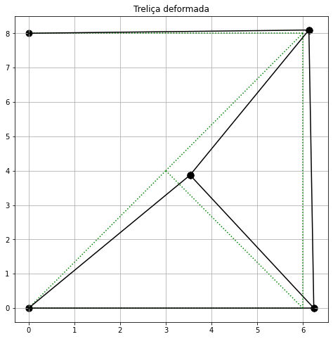

```python
e = 2000           #escala da deformação
for barra in barras.index:
    # Vamos passar os nós para as variáveis N1 e N2
    N1 = barras.loc[barra, 'N1']
    N2 = barras.loc[barra, 'N2']

    # Agora vamos acessar as coordendas de cada um dos nós
    x1, y1  = nos.loc[N1, ['X','Y']]
    x2, y2  = nos.loc[N2, ['X','Y']]

    DX = np.array([U[2*N1-2],U[2*N2-2]])
    DY = np.array([U[2*N1-1],U[2*N2-1]])
    y = [y1,y2]
    x = [x1,x2]
    plt.figure(1,figsize=(8,8))
    plt.plot(x,y,'g:')
    plt.plot(x+DX*e,y+DY*e,'black')
    plt.scatter(x+DX*e,y+DY*e, s=80,marker ='o',color ='black')
    plt.grid(True)

_=plt.title('Treliça deformada')
```

O cálculo das reações de apoio é feito a partir do produto da matriz de rigidez pelos deslocamentos.

```python
R = np.dot(Kcompleta,U)
print(R)
```

```
[-1.77899576e+05 -1.03866101e+05  0.00000000e+00  1.03866101e+05
  2.00000000e+05 -1.45519152e-11  1.45519152e-11  0.00000000e+00
 -2.21004243e+04  0.00000000e+00]
```

Agora, para a realização da plotagem, é necessário escolher apenas os graus de liberdade que são restritos.

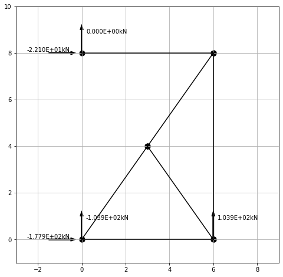

```python
plt.figure(1,figsize=(8,8))
plt.xlim(-3,9)
plt.ylim(-1,10)

# Plotagem dos apoios e das forças
for no in nos.index:
    X,Y,RX,RY= nos.loc[no,['X','Y','RX','RY']]

    gl1 = 2*no - 1
    gl2 = 2*no
    Fx = R[gl1-1]
    Fy = R[gl2-1]

    # Se RX restrito aplica sobre gl de X
    if RX == 1:
        plt.arrow(X-1.5,Y,1,0,width =0.05,color='k')
        plt.text(X-2.5,Y,'{:.3E}kN'.format(Fx/1000),va='bottom')
    if RY == 1:
        plt.arrow(X,Y,0,1,width =0.05,color='k')
        plt.text(X+0.2,Y+0.8,'{:.3E}kN'.format(Fy/1000),va='bottom')

# Plotagem das barras
for barra in barras.index:
    # Vamos passar os nós para as variáveis N1 e N2
    N1 = barras.loc[barra, 'N1']
    N2 = barras.loc[barra, 'N2']

    # Agora vamos acessar as coordendas de cada um dos nós
    x1, y1 = nos.loc[N1, ['X','Y']]
    x2, y2 = nos.loc[N2, ['X','Y']]
    y = [y1,y2]
    x = [x1,x2]

    plt.plot(x,y,'black')
    plt.scatter(x,y, s=80,marker ='o',color ='black')
    plt.grid(True)
```

## 9. Determinação dos esforços

Para finalizar a análise, calcula-se os esforços atuantes em cada elemento, para isso, realiza-se o script abaixo:

```python
Esf = []

for barra in barras.index:
    # Vamos importar as propriedades necessárias para construção da matriz local e da matriz de rotação
    L   = barras.loc[barra, 'L']
    sen = barras.loc[barra, 'sen']
    cos = barras.loc[barra, 'cos']
    A   = barras.loc[barra, 'A']
    E   = barras.loc[barra, 'E']
    N1  = barras.loc[barra, 'N1']
    N2  = barras.loc[barra, 'N2']

    # Matriz de rigidez no sistema local
    Kl = E*A/L*np.array([[ 1, 0,-1, 0],
                         [ 0, 0, 0, 0],
                         [-1, 0, 1, 0],
                         [ 0, 0, 0, 0]])

    # Matriz de rotação
    Mrot = np.array([[ cos,  sen,    0,   0],
                     [-sen,  cos,    0,   0],
                     [    0,   0,  cos, sen],
                     [    0,   0, -sen, cos]])
    # Recebendo os deslocamentos referentes ao elemento em análise
    Ul = np.zeros(4)
    Ul[0] = U[2*N1-2]
    Ul[1] = U[2*N1-1]
    Ul[2] = U[2*N2-2]
    Ul[3] = U[2*N2-1]

    # Realizando o equilíbrio local

    F = np.dot(Kl,np.dot(Mrot,Ul))

    # Salvando o terceiro valor do vetor de forças por convenção de sinais.
    Esf.append(F[2])
print (Esf)
```

```
[99999.99999999997, 129832.62611975479, -166666.66666666666, 29467.23243752945, -36834.04054691178, 22100.424328147114]
```

Agora, plota-se os esforços. As barras comprimidas estão identificadas pela cor azul e as tracionadas pela cor vermelha.

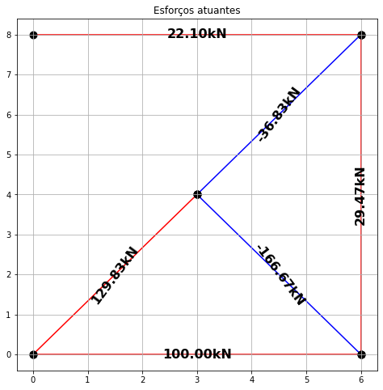

```python
for barra in barras.index:
    # Vamos passar os nós para as variáveis N1 e N2
    N1 = barras.loc[barra, 'N1']
    N2 = barras.loc[barra, 'N2']
    ax = Esf[barra-1]
    cos = barras.loc[barra, 'cos']
    sen = barras.loc[barra, 'sen']
    tg  = sen/cos
    # Agora vamos acessar as coordendas de cada um dos nós
    x1, y1  = nos.loc[N1, ['X','Y']]
    x2, y2  = nos.loc[N2, ['X','Y']]
    y = [y1,y2]
    x = [x1,x2]

    plt.figure(1,figsize=(8,8))
    if ax>0:
        cor = 'r'
    elif ax == 0:
        cor = 'k'
    else:
        cor = 'b'
    plt.plot(x,y,cor,zorder = -1)

    plt.text(np.mean(x),np.mean(y),'{:.2f}kN'.format(ax/1000),rotation =180*np.arctan(tg)/np.pi,
            horizontalalignment='center',
            verticalalignment='center',
            size = 16,
            weight = 'bold')

    plt.scatter(x,y, s=80,marker ='o',color ='black')

_=plt.title('Esforços atuantes')
plt.grid(True)
```